# Project Business Statistics: E-news Express

### Bivariate Analysis

#### Language preferred vs Time spent on the page

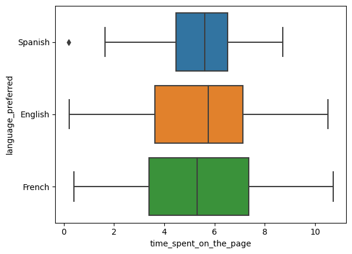

```python
#dissplaying language preferred and time spent on time through plot
sns.boxplot(df,x="time_spent_on_the_page",y="language_preferred");
```

#### Observations:

- one spanish language user spent less then one minuates.
- French language user spent average time is around 5 minuates.
- spanish and english language user spent average time is around 6 minuates.

#### Time spent on the page vs Converted

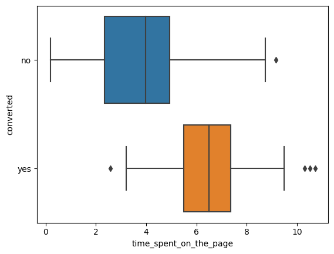

```python
#dissplaying converted and time spent on time through plot
sns.boxplot(df,x="time_spent_on_the_page",y="converted");
```

#### Landing page vs Time spent on the page

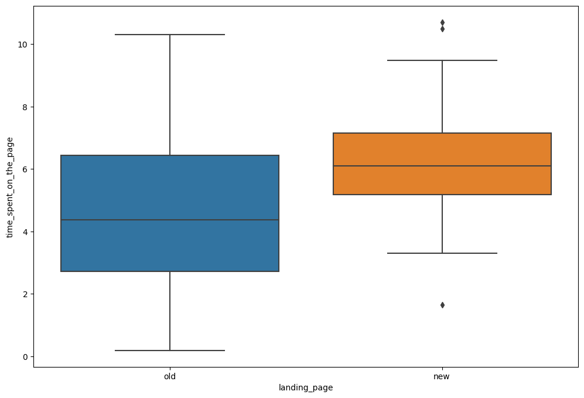

```python
#dissplaying landing page and time spent on time through plot
plt.figure(figsize=(12,8))
sns.boxplot(data=df,x='landing_page',y='time_spent_on_the_page');
```

#### Observations:

- user spent more time is new page compare to old page.

## 1. Do the users spend more time on the new landing page than the existing landing page?

### Visual Analysis

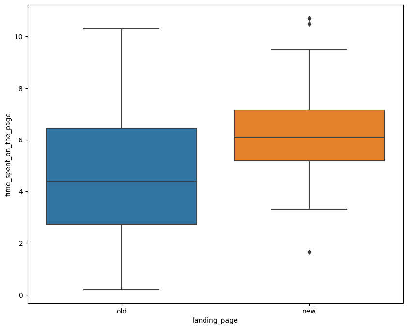

```python
# displaying plot of the time spent on the new page and the time spent on the old page
plt.figure(figsize=(10,8))
sns.boxplot(df,x = 'landing_page', y = 'time_spent_on_the_page')
plt.show()
```

### Step 1: null and alternate hypotheses

$H_0$: the users spend time on the new landing page and the existing landing page is equal.

$H_a$: the users spend more time on the new landing page than the existing landing page.

### Step 2: Appropriate test

```python
stats.shapiro(df["time_spent_on_the_page"])
```

```
ShapiroResult(statistic=0.9887408018112183, pvalue=0.5643193125724792)
```

#### Let's test whether the T-test assumptions are satisfied or not

We can use two sample T-test for this problem.

This is a one-tailed **(right tailed)** test concerning two population means from two independent populations. The population standard deviations are unknown. based on the information, selecting two sample T test (independent) **ttest_ind**.

### Step 3: significance level

As given in the problem statement, we select $\alpha = 0.05$.

### Step 4: Collecting and preparing data

```python
# creating dataframe of new page time spending by user
time_tsnp_new = df[df['landing_page'] == 'new']['time_spent_on_the_page']
# creating dataframe of old page time spending by user
time_tsop_old = df[df['landing_page'] == "old"]['time_spent_on_the_page']
```

```python
#checking std of new and old page
print('The sample std of the time spent on the new page is', round(time_tsnp_new.std(),4))
print('The sample std of the time spent on the new page is', round(time_tsop_old.std(),4))
```

```
The sample std of the time spent on the new page is 1.817
The sample std of the time spent on the new page is 2.582
```

### Step 5: Calculating the p-value

```python
# Calculating the t-test  and p-value of old page and new page,alternative would be greater.
t, p_value = stats.ttest_ind(time_tsnp_new, time_tsop_old,alternative="greater")
# p and t-value
print("The p-value is:",p_value)
print("The t-static is:", round(t,5))
```

```
The p-value is: 0.0001316123528095005
The t-static is: 3.78677
```

### Step 6: Comparing the p-value with $\alpha$

```python
# conclusion based on p-value
if p_value < 0.05:
    print(f'As the p-value is',round(p_value,5), 'less than the level of significance (alpha) 0.05, we reject the null hypothesis.')
else:
    print(f'As the p-value is', round(p_value,5), 'greater than the level of significance (alpha) 0.05, we fail to reject the null hypothesis.')
```

```
As the p-value is 0.00013 less than the level of significance (alpha) 0.05, we reject the null hypothesis.
```

### Step 7: inference

As the p-value (**0.00013**) is less than the significance level alpha( **0.05**),so we reject the null hypothesis. Thus we have enough evidence to say that the users spend more time on the new landing page than the existing landing page.

**A similar approach can be followed to answer the other questions.**

## 2. Is the conversion rate (the proportion of users who visit the landing page and get converted) for the new page greater than the conversion rate for the old page?

### Visual Analysis

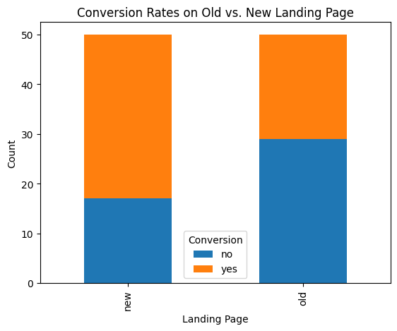

```python
# using Bar chart to comparing conversion rates on old and new landing pages
conversion_by_page = df.groupby('landing_page')['converted'].value_counts().unstack().plot(kind='bar', stacked=True)
plt.title('Conversion Rates on Old vs. New Landing Page')
plt.xlabel('Landing Page')
plt.ylabel('Count')
plt.legend(title='Conversion')
plt.show()
```

### Step 1: null and alternate hypotheses

$H_0:$ conversion rate for the new page and conversion rate for the old page is equal

$H_a:$ conversion rate for the new page is greater than the conversion rate for the old page

### Step 2: Appropriate test

#### Let's test whether the Z-test assumptions are satisfied or not

- Binomally distributed population - Yes, a converted is either yes or no.
- Random sampling from the population - Yes, we are informed the collected sample is a simple random sample.
- Can the binomial distribution approximated to normal distribution - Yes., according to clt. The standard thing is to check whether np and n(1-p) are greater than or equal to 10. Here, n and p refer to the sample size and sample proportion respectively.

This is a one-tailed **(right-tailed)** test concerning two population proportions from two independent populations. Based on this information, selecting two propotion ztest (**proportions_ztest**).

### Step 3: significance level

As given in the problem statement, we select α = 0.05.

### Step 4: Collecting and preparing data

```python
# calculating the number of converted users in the treatment group
new_pcop = df[df['group'] == 'treatment']['converted']
new_converted=(new_pcop=="yes").sum()
# calculating the number of converted users in the control group
old_pcop = df[df['group'] == 'control']['converted']
old_converted = (old_pcop == "yes").sum()
print("new page visited and converted is", round(new_converted, 4),
      "\nand old page visited and converted is", round(old_converted, 4))
```

```
new page visited and converted is 33
and old page visited and converted is 21
```

```python
#calculating the number of observation of control
obs_control=(df["group"] == "control").sum()
obs_control
#calculating the number of observation of treatment
obs_treatment=(df["group"] == "treatment").sum()
print("the number of observation of control is",obs_control)
print("the number of observation of treatment is",obs_treatment)
```

```
the number of observation of control is 50
the number of observation of treatment is 50
```

```python
# importing the library
from statsmodels.stats.proportion import proportions_ztest


# calculating p-value
prop_ztest, p_value = proportions_ztest([new_converted, old_converted], [obs_control, obs_treatment], alternative="larger")
print('The p-value is', p_value)
```

```
The p-value is 0.008026308204056278
```

### Step 6: Compare the p-value with $\alpha$

```python
# conclusion based on p-value
if p_value < 0.05:
    print(f'As the p-value', round(p_value,5),' is less than the level of significance, we reject the null hypothesis.')
else:
    print(f'As the p-value', round(p_value,5), 'is greater than the level of significance, we fail to reject the null hypothesis.')
```

```
As the p-value 0.00803  is less than the level of significance, we reject the null hypothesis.
```

### Step 7: inference

As the p-value (**0.00803**) is less than the significance level (**0.05**), we reject the null hypothesis. Thus we have enough evidence to say that the conversion rate for the new page is greater than the conversion rate for the old page.

## 3. Is the conversion and preferred language are independent or related?

### Visual Analysis

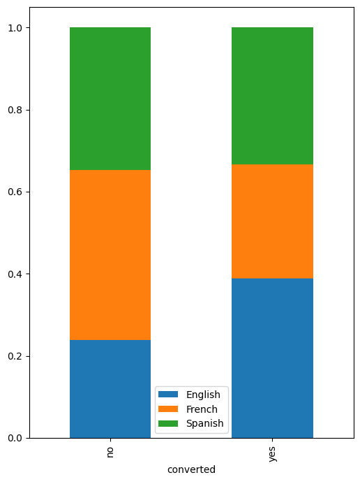

```python
#dissplaying converted and language preferred through plot
pd.crosstab(df['converted'],df['language_preferred'],normalize='index').plot(kind="bar", figsize=(6,8), stacked=True)
plt.legend()
plt.show()
```

### Step 1: null and alternate hypotheses

$H_0:$ converted status is Independent on the preferred language

$H_a:$ converted status dependent or releated on the preferred language

### Step 2: Appropriate test

### Let's test whether the assumptions are satisfied or not

- Categorical variables - Yes
- Expected value of the number of sample observations in each level of the variable is at least 5 - Yes, the number of observations in each level is greater than 5.
- Random sampling from the population - Yes, we are informed that the collected sample is a simple random sample.

This is a problem of the test of independence, concerning two categorical variables - converted status and preferred language. Based on the information, selecting chi-square test (**chi2_contingency**).

### Step 3: the significance level

As given in the problem statement, we select α = 0.05.

### Step 4: Collecting and preparing data

```python
# creating contingency table
contingency_table = pd.crosstab(df['converted'], df['language_preferred'])

contingency_table
```

| language_preferred converted | English | French | Spanish |
| --- | --- | --- | --- |
| no | 11 | 19 | 16 |
| yes | 21 | 15 | 18 |

### Step 5: Calculating the p-value

```python
# importing required library
from scipy.stats import chi2_contingency

# calculating p-value
chi2, p_value, dof, expected = chi2_contingency(contingency_table)
# Print the results of the chi-square test
print('The p-value is',p_value,4)
print('chi2 =', chi2)
print('dof =', dof)
print('expected =', expected)
```

```
The p-value is 0.21298887487543447 4
chi2 = 3.0930306905370837
dof = 2
expected = [[14.72 15.64 15.64]
 [17.28 18.36 18.36]]
```

### Step 6: Comparing the p-value with $\alpha$

```python
# conclusion based on p-value
if p_value < 0.05:
    print(f'As the p-value is', round(p_value,4),' less than the level of significance, we reject the null hypothesis.')
else:
    print(f'As the p-value is', round(p_value,4) ,' greater than the level of significance, we fail to reject the null hypothesis.')
```

```
As the p-value is 0.213  greater than the level of significance, we fail to reject the null hypothesis.
```

## 4. Is the time spent on the new page same for the different language users?

### Visual Analysis

```python
# creating a new DataFrame for users for the new page
new_data = df[df['landing_page'] == 'new']
```

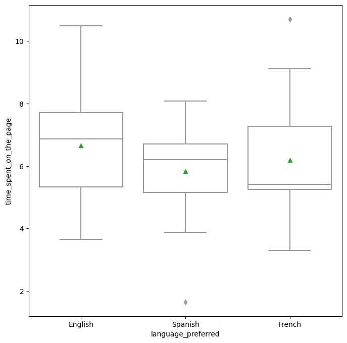

```python
#displaying plot the time spent on the new page for different language users
plt.figure(figsize=(8,8))
sns.boxplot( data = new_data,x ='language_preferred', y ='time_spent_on_the_page', showmeans = True,color="white");
```

```python
# calculating the mean time spent on the new page for different language user
new_data.groupby(['language_preferred'])['time_spent_on_the_page'].mean()
```

```
language_preferred
English    6.663750
French     6.196471
Spanish    5.835294
Name: time_spent_on_the_page, dtype: float64
```

### Step 1: null and alternate hypotheses

$H_0:$ time spent on the new page is same for the different language users

$H_a:$ time spent on the new page is not same for the different language users .

### Step 2: Appropriate test

### Let's test whether the assumptions are satisfied or not

- The populations are normally distributed - Yes. i had check it by shapiro initially.
- Samples are independent simple random samples - Yes, we are informed that the collected sample is a simple random sample.
- Population variances are equal - Yes(it is approx. equal)

This is a problem, concerning three population means. Based on this information, selecting one way anova test (**f_oneway**).

### Step 3: significance level

As given in the problem statement, we select α = 0.05.

### Step 4: Collecting and preparing data

```python
# creating dataframe of the time spent on the new page by English language users
time_spent_by_ep = new_data[new_data['language_preferred']=="English"]['time_spent_on_the_page']
# creating data frames of the time spent on the new page by French language users
time_spent_by_fp = new_data[new_data['language_preferred']=="French"]['time_spent_on_the_page']
#creating data frames of the time spent on the new page by Spanish language users
time_spent_by_sp = new_data[new_data['language_preferred']=="Spanish"]['time_spent_on_the_page']
print("English preferred user spent time on the new page is",time_spent_by_ep.sum())
print("French preferred user spent time on new the page is",time_spent_by_fp.sum())
print("Spanish preferred user spent time on the new page is",time_spent_by_sp.sum())
```

```
English preferred user spent time on the new page is 106.62
French preferred user spent time on new the page is 105.34
Spanish preferred user spent time on the new page is 99.2
```

### Step 5: Calculating the p-value

```python
#importing annova f test oneway
from scipy.stats import f_oneway

# calculating the p-value
f, p_value =f_oneway(time_spent_English, time_spent_French, time_spent_Spanish)
#result
print('The p-value is', round(p_value,5))
print('f =', f)
```

[output not shown]

### Step 6: Comparing the p-value with $\alpha$

```python
#conclusion based on p-value
if p_value < 0.05:
    print(f'As the p-value is', round(p_value,5), ' less than the level of significance, we reject the null hypothesis.')
else:
    print(f'As the p-value is', round(p_value,5), ' greater than the level of significance, we fail to reject the null hypothesis.')
```

```
As the p-value is 0.43204  greater than the level of significance, we fail to reject the null hypothesis.
```

## Conclusion and Business Recommendations

*Time Spent on Landing Pages:*

**Conclusion:** The numbers show that users spend more time on the new landing page compared to the old one (p-value = 0.00013, less than 0.05).

**Recommendation:** Stick with the new landing page on E-news Express. Users seem to love it, so let's keep it as the main spot for news exploration.

*Conversion Rate:*

**Conclusion:** The data indicates a higher conversion rate on the new page than the old one (p-value = 0.00803, less than 0.05).

**Recommendation:** It's a win! Promote the new page actively on E-news Express. It's pulling in more conversions, so let's spread the word for even more success.

*Language and Conversion Status:*

**Conclusion:** The stats suggest that the converted status is not linked to preferred language (p-value = 0.213, greater than 0.05).

**Recommendation:** No need for language-specific strategies! E-news Express can keep it simple and inclusive in all communications and content.

**Time Consistency Across Languages:**

**Conclusion:** Users with different languages seem to spend a similar amount of time on the new page (p-value = 0.43204, greater than 0.05).

**Recommendation:** E-news Express is already doing something right! The time spent is consistent, offering a universal experience. Keep it up for a seamless visit for everyone, no matter their language preference.

### *Smart Moves for E-news Express:*

**New Page Experience:** Since users love the new landing page, make sure it's optimized for the best news exploration experience.

**Conversion Success:** Promote the new page actively to attract more readers.

**Communication Approach:** Keep your messages simple and inclusive. No need to complicate things based on language preferences.

**Consistent User Experience:** Maintain the consistency in time spent. Users appreciate a smooth experience, and E-news Express should continue providing that across all languages

-------------------------------------:::::----------------------------:::::--------**The End**--------------------------------------------------:::------------------------